# Part II - (Ford GoBike System Report )

## by (ANAH SUNDAY CHUKWUJEKWU)

## Investigation Overview

- This report is aimed at showing when most trips where taken based on the week day as well as the time of the day by clients on the bike platform.
- This report also aims to show the relationship between the period when trips are being taken and the nature of the clients either they are the platform members or casual customers.

## Dataset Overview

- This data set includes information about individual rides made in a bike-sharing system covering the greater San Francisco Bay area , the dataset consists of 183,412 rows and 16 columns. the columns are namely ( duration_sec, start_time, end_time, start_station_is, start_station_name, start_station_latitude, start_station_longitude, end_station_id, end_station_name, end_station_latitude, end_station_longitude, bike_id, user_type, member_birth_year, member_gender, bike_share_for_all_trip)

## (Distribution of Trips Duration)

- Charting the diistribution of trip duration in seconds on a log scale transformation, to show the spread of trip duration on the platform.

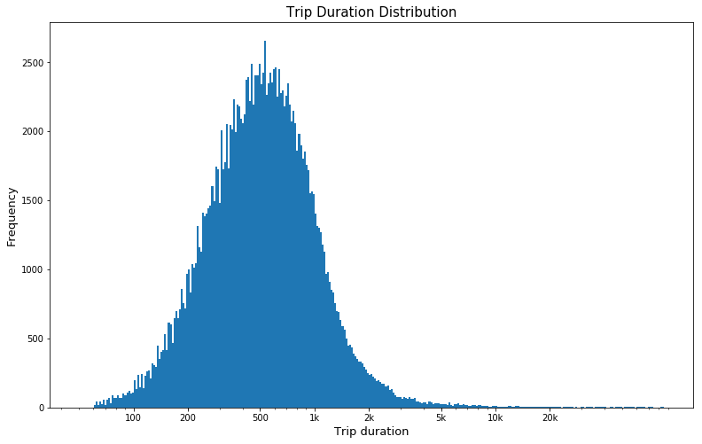

The visuals shows a normal distribution increasing from 100 seconds whilst reaching a peak around 500-700 seconds before gently tailing off to about 5000 seconds.

### ( Distribution of Trips by Day of Week)

- Charting the frquency of trips by the spread along the week days to ascertain peak periods of the week

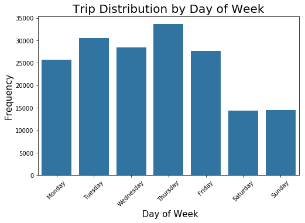

## (Trip Duration based on week day and user type)

- Examining the relationship between trips duration based on the day of week the trip was undertaken and the type of user.

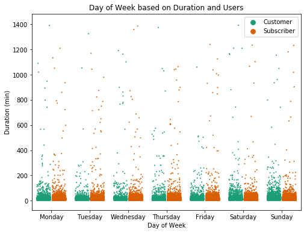

The presence of outliers skews the data , and in order to get an indepth look at the data will involve stripping off the outliers

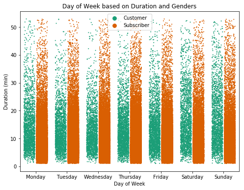

Examining the relationship between the features shows that the spread of the subscribers were typically for shorter trips , they also embarked on longer trips which spread accross all the week days, as opposed to casual customers who did tend to under take longer trips during the weekends.

## (Relationship Between Hour of the Day and Users)

- Charting the relationship between the trip duration by hour of the day based on the user type of riders on the platform

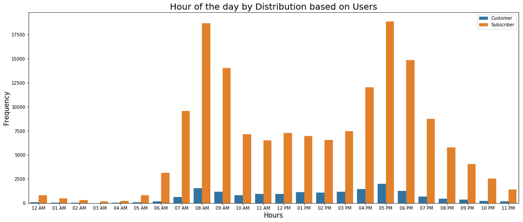

- The peak hours of riders who are subscribers using the platform are peaked on two points, the 8am and the 5pm, with both having similar peaks, with casual users also showing a mild affinity to spike around those times also
- From that one can deduce that the users on the platform who are members typically use the platform for work thus leading to such spike in usage on those hours of the day.